# null

```r
analyse.residuen(0.4999, 3.0017, reg4)
```

```
#> [1] 0.0001090909
```

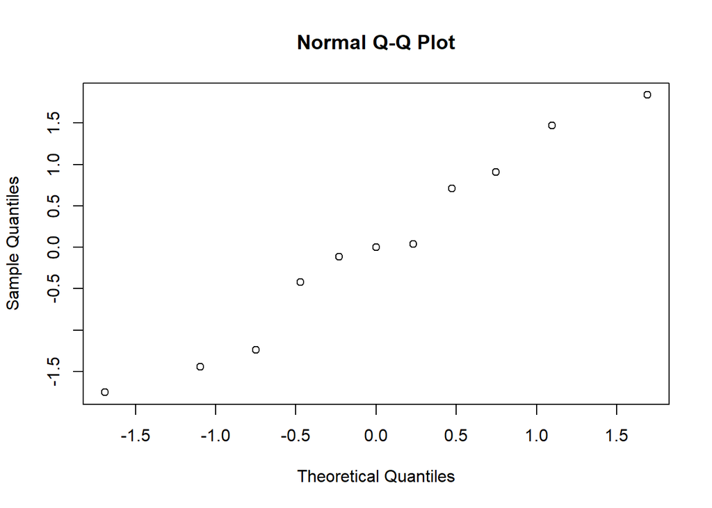

```
#>  [1]  7.0009  7.0009  7.0009  7.0009  7.0009  7.0009  7.0009 12.4998
#>  [9]  7.0009  7.0009  7.0009
```

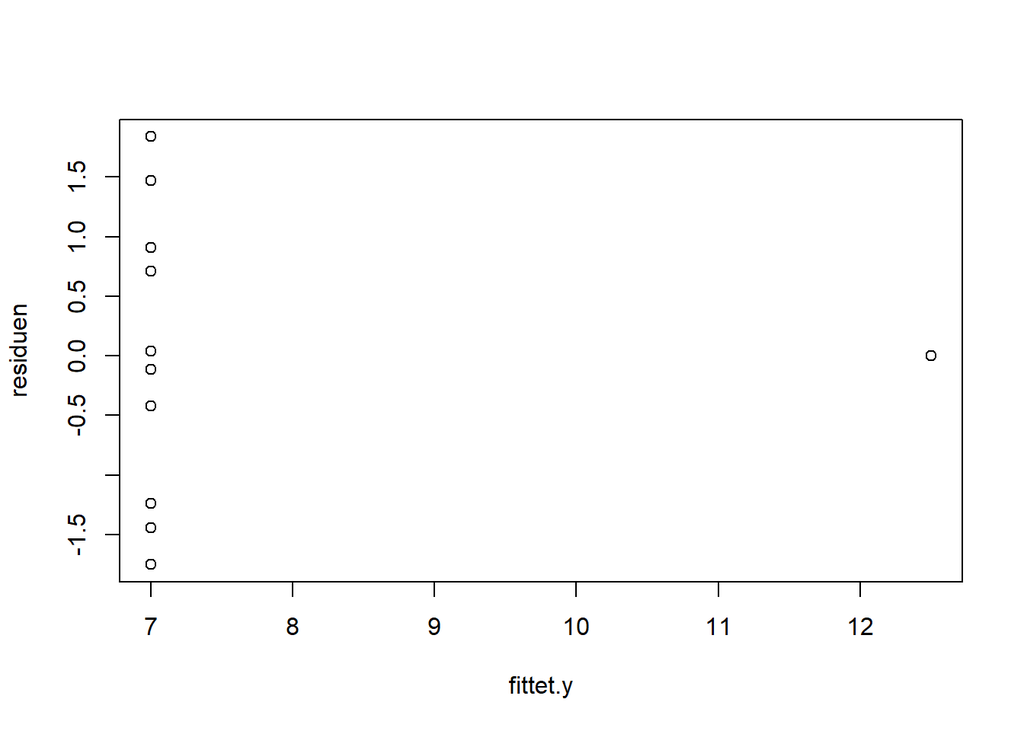

```r
#or just: plot(lm<i>)
```

23a)

```r
install.packages("vcd")
```

```
#> Error in contrib.url(repos, "source"): trying to use CRAN without setting a mirror
```

```r
library("vcd")
data2019 <- read.csv(file="UmfrageBis2019.csv", header=TRUE, sep=";")
table_abs <- structable(data2019$Geschlecht ~ data2019$Fussballfan)
table_abs
```

```
#>                      data2019$Geschlecht  m  w
#> data2019$Fussballfan
#> ja                                       28  3
#> nein                                     43 27
```

```r
table_rel <- prop.table(table_abs)
table_rel
```

```
#>                      data2019$Geschlecht          m          w
#> data2019$Fussballfan
#> ja                                       0.27722772 0.02970297
#> nein                                     0.42574257 0.26732673
```

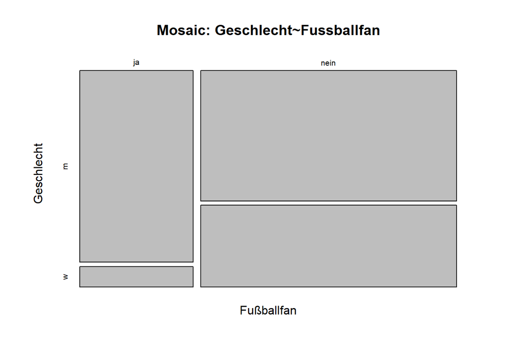

```r
mosaicplot(table_abs, xlab = "Fußballfan", ylab = "Geschlecht", main= "Mosaic: Geschlecht~Fussballfan")
```

Interpretation: Es ist erkennbar, dass eine Abhängigkeit zwischen den Merkmalen Geschlecht und Fußballfan besteht, da die Zeilen bzw. Spalen unterschiedliche Breiten aufweisen. Der größte Anteil der Befragten ist kein Fußballfan und unter denjenigen, die Fußballfan sind, ist der Großteil männlich. “Als Mann ist man eher Fußballfan”

23b)

Das Merkmal Musikalitaet ist im Gegensatz zum Merkmal Fussballfan nicht binär und kann somit mehr als 2 verschiedene Werte annehmen. In der Analyse ist dabei zu berücksichtigen, dass es keine Vier-Felder-Tafel gibt. Auch muss bei der Interpretation des Mosaic Plots darauf geachtet werden, dass das Merkmal Musikalitaet evtl. nicht in richtiger Reihenfolge sortiert ist.

```r
abs_table2 <- structable(data2019$Geschlecht ~ data2019$Musikalitaet)
abs_table2
```

```
#>                       data2019$Geschlecht  m  w
#> data2019$Musikalitaet
#>                                            1  0
#> etwas                                     20 11
#> gar nicht                                 22  8
#> mittel                                    25  8
#> sehr                                       3  3
```

```r
rel_table2 <- prop.table(abs_table2)
rel_table2
```

```
#>                       data2019$Geschlecht          m          w
#> data2019$Musikalitaet
#>                                           0.00990099 0.00000000
#> etwas                                     0.19801980 0.10891089
#> gar nicht                                 0.21782178 0.07920792
#> mittel                                    0.24752475 0.07920792
#> sehr                                      0.02970297 0.02970297
```

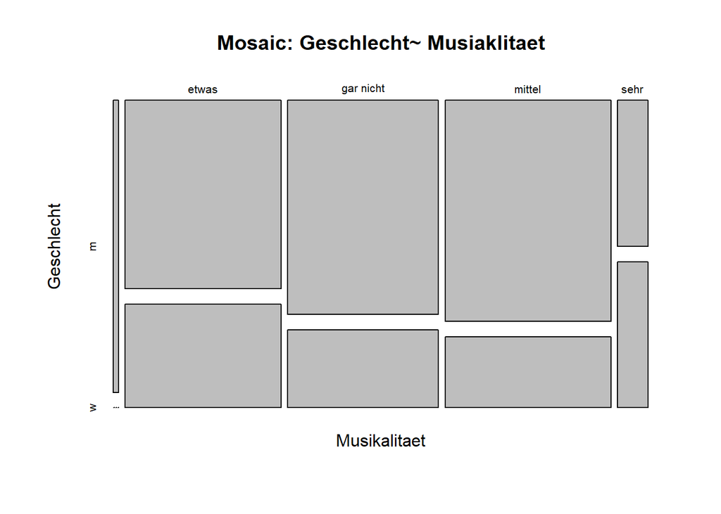

```r
mosaicplot(abs_table2, xlab = "Musikalitaet", ylab = "Geschlecht", off = 5, main = "Mosaic: Geschlecht~ Musiaklitaet")
```

Es ist kein deutlicher Zusammenhang zwischen Geschlecht und Musikalitaet erkennbar, da die Mehrzahl der Spalten eine ähnliche Breite aufweisen. (Die Auspräung NA wird nicht berücksichtigt.)

23c)

```r
abs_table3 <- table(data2019$Haarfarbe, data2019$Musikalitaet)
abs_table3
```

```
#>
#>               etwas gar nicht mittel sehr
#>   blond     0     7        10     10    3
#>   braun     1    18        19     20    3
#>   rot       0     2         0      0    0
#>   schwarz   0     4         1      2    0
#>   sonstige  0     0         0      1    0
```

```r
rel_table3 <- prop.table(abs_table3)
rel_table3
```

```
#>
#>                            etwas  gar nicht     mittel       sehr
#>   blond    0.00000000 0.06930693 0.09900990 0.09900990 0.02970297
#>   braun    0.00990099 0.17821782 0.18811881 0.19801980 0.02970297
#>   rot      0.00000000 0.01980198 0.00000000 0.00000000 0.00000000
#>   schwarz  0.00000000 0.03960396 0.00990099 0.01980198 0.00000000
#>   sonstige 0.00000000 0.00000000 0.00000000 0.00990099 0.00000000
```

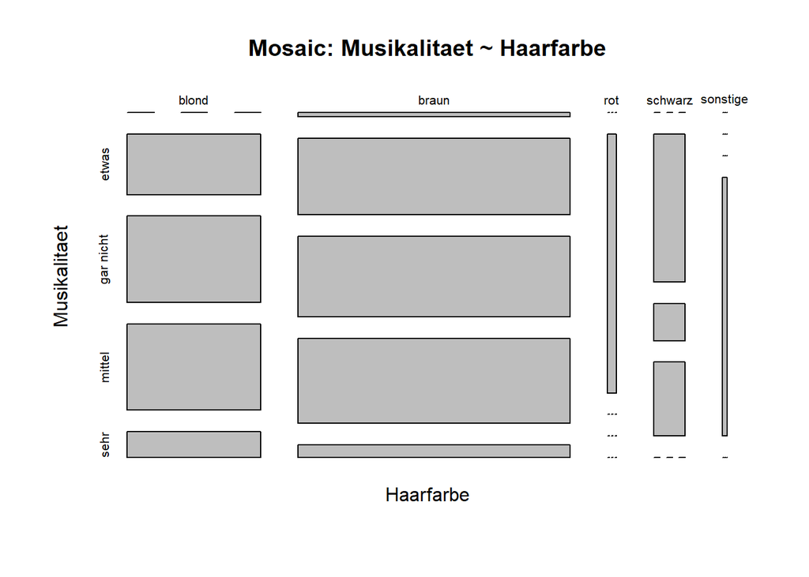

```r
mosaicplot(abs_table3, xlab = "Haarfarbe", ylab = "Musikalitaet", off = 25, main = "Mosaic: Musikalitaet ~ Haarfarbe")
```

Es kann kein Zusammenhang festgestellt werden. Jedochkönnte aus dieser Stichprobe herausgelesen werden, dass alle Rothaarigen nur etwas musikalisch sind.

23d) Der Mosaic Plot aus 23c) zeigt am ehesten Unabhängigkeit zwischen den beiden Merkmalen, da die Zeilenbreiten der Merkmalskombinationen eine ähnliche Breite aufweisen. Nur bei den Merkmalsausprägungen rot, schwarz und sonstige des Merkmals Haarfarbe ist eine unterschiedliche Breite dargestellt, was auf die geringe ANzahl der Beobachtungen zurückgeführt wird.